# Demand 2

September 14, 2018

## Pregame

- I’m going to email those of you who have lower than a 60% after the homework is submitted today to discuss options.
- First Quiz is 9/28, two weeks from today. I’ll make a practice quiz available sometime next week.

## Feedback

### Good:

- Document camera was good.

### Needs improvement:

- Go over the writing assignment (we did this in the last class? #confused.gif).

## Feeling conflicted

[figure not shown]

## Feeling conflicted

[figure not shown]

## Feeling conflicted

[figure not shown]

## Feeling conflicted

[figure not shown]

## Aggregate Demand

- **Aggregate demand** - *The sum of all consumer demand. Demand curves are summed horizontally.*

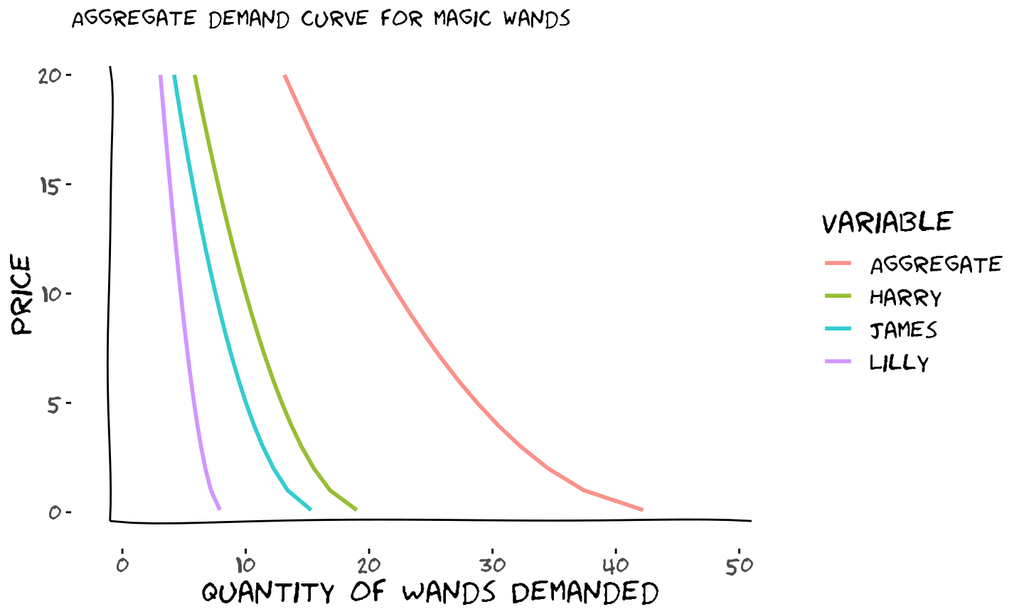

## Substitutes and complements

- **Substitutes** - Two goods are substitutes if a decrease in the price of one good **decreases** demand for the other good.

*Examples include food away from home (FAFH) and food at home (FAH).*

- **Complements** - Two goods are complements if a decrease in the price of one good **increases** demand for the other good.

*Examples include gas prices and milk.*

*Review Practice Problem 3.*

## Normal and inferior goods

- **Normal goods** - A normal good is one in which an increase in income **increases** demand for that good or vice-versa.

*Examples include pretty much all goods.*

- **Inferior goods** - Goods are inferior if an increase in income **decreases** demand for that good or vice-versa.

*Examples?*

## Universal Basic Income

- A Universal Basic Income (UBI) is a proposal to remove various social benefits and provide instead a basic income to everyone.

*What would a UBI do to spending for housing?*

- How **elastic** is demand for housing? How much does demand change as price changes?
- How much would a UBI shift demand for housing, and in which direction?
- How would a UBI shift demand for food at home? For dining out?

## Wrapping Up

- Complete the [knowledge check](https://goo.gl/forms/4Axrj5UUIgu8xZ4E3) for today’s participation point.
- Please provide [feedback](https://goo.gl/forms/8SiOwdi19kN8cINJ3) on today’s lecture.